# Lecture 12

Comparative structure analysis of Adenylate Kinase (pt 2)

Barry Grant < http://thegrantlab.org/bimm143/ >  
2020-02-12 (20:22:51 on Wed, Feb 12)

# Background

The goal of this hands-on session is to perform **principal component analysis** (PCA) on the complete collection of Adenylate kinase structures in the protein data-bank (PDB).

Adenylate kinase (often called simply Adk) is a ubiquitous enzyme that functions to maintain the equilibrium between cytoplasmic nucleotides essential for many cellular processes. Adk operates by catalyzing the reversible transfer of a phosphoryl group from ATP to AMP. This reaction is accompanied by a rate limiting conformational transition. Here we analyze all currently available Adk structures to reveal detailed features and mechanistic principles of these essential transitions.

The **bio3d package** `pca()` function provides a convenient interface for performing PCA of biomolecular structure data. As we have discussed in previous classes, PCA is a statistical approach used to transform large data-sets down to a few important components that usefully describe the directions where there is most variance. In terms of protein structures PCA can be used to capture major structural variations within a set of structures (a.k.a. structure ensemble). This can make interpreting major conformational states (such as ‘active’ and ‘inactive’ or ‘ligand bound’ and ‘un-bound’ states) and structural mechanisms for activation or regulation more clear.

## Overview

Starting from only one Adk PDB identifier (**PDB ID: 1AKE**) we will search the entire PDB for related structures using BLAST, fetch, align and superpose the identified structures, perform PCA and finally calculate the normal modes of each individual structure in order to probe for potential differences in structural flexibility.

## Setup

We will begin by first installing the packages we need for today’s session.

```r
# Install packages in the R console not your Rmd

install.packages("bio3d")
install.packages("ggplot2")
install.packages("ggrepel")
install.packages("devtools")
install.packages("BiocManager")

BiocManager::install("msa")
devtools::install_bitbucket("Grantlab/bio3d-view")
```

- **Q.** Which of the packages above is found only on BioConductor and not CRAN?
- **Q.** Which of the above packages is not found on BioConductor or CRAN?:
- **Q.** True or False? Functions from the devtools package can be used to install packages from GitHub and BitBucket?

The `install.packages()` function is used to install packages from the main **CRAN** repository for R packages. **BioConductor** is a separate repository of R packages focused on high-throughput biomolecular assays and biomolecular data. Packages from BioConductor can be installed using the `BiocManager::install()` function. Finally, R packages found on GitHub or BitBucket can be installed using `devtools::install_github()` and `devtools::install_bitbucket()` functions.

# 1. Search and retrieve ADK structures

Below we perform a blast search of the PDB database to identify related structures to our query Adenylate kinase (ADK) sequence. In this particular example we use function `get.seq()` to fetch the query sequence for chain A of the PDB ID 1AKE and use this as input to `blast.pdb()`. Note that `get.seq()` would also allow the corresponding UniProt identifier.

```r
library(bio3d)
aa <- get.seq("1ake_A")
```

```
## Fetching... Please wait. Done.
```

```r
aa
```

```
##              1        .         .         .         .         .         60
## pdb|1AKE|A   MRIILLGAPGAGKGTQAQFIMEKYGIPQISTGDMLRAAVKSGSELGKQAKDIMDAGKLVT
##              1        .         .         .         .         .         60
##
##             61        .         .         .         .         .         120
## pdb|1AKE|A   DELVIALVKERIAQEDCRNGFLLDGFPRTIPQADAMKEAGINVDYVLEFDVPDELIVDRI
##             61        .         .         .         .         .         120
##
##            121        .         .         .         .         .         180
## pdb|1AKE|A   VGRRVHAPSGRVYHVKFNPPKVEGKDDVTGEELTTRKDDQEETVRKRLVEYHQMTAPLIG
##            121        .         .         .         .         .         180
##
##            181        .         .         .   214
## pdb|1AKE|A   YYSKEAEAGNTKYAKVDGTKPVAEVRADLEKILG
##            181        .         .         .   214
##
## Call:
##   read.fasta(file = outfile)
##
## Class:
##   fasta
##
## Alignment dimensions:
##   1 sequence rows; 214 position columns (214 non-gap, 0 gap)
##
## + attr: id, ali, call
```

- **Q.** How many amino acids are in this sequence, i.e. how long is this sequence?

Now we can use this sequence as a query to BLAST search the PDB to find similar sequences and structures.

```r
# Blast or hmmer search
#b <- blast.pdb(aa)
```

> **Side-note**: Due to the number of students in this class session this command, which uses online NCBI blast service, may time-out. If this happens please jump ahead to the next *Side-note* below to skip running the actual blast search.

The function `plot.blast()` facilitates the visualization and filtering of the Blast results. It will attempt to set a seed position to the point of largest drop-off in normalized scores (i.e. the biggest jump in E-values). In this particular case we specify a cutoff (after initial plotting) of to include only the relevant E.coli structures:

```r
# Plot a summary of search results
#hits <- plot(b)
```

```r
# List out some 'top hits'
#head(hits$pdb.id)
```

> **Side-note**: If blast did not return results (likely due to the large number of simultaneous requests from the class) you can use the following vector of PDB IDs

```r
hits <- NULL
hits$pdb.id <- c('1AKE_A','4X8M_A','6S36_A','6RZE_A','4X8H_A','3HPR_A','1E4V_A','5EJE_A','1E4Y_A','3X2S_A','6HAP_A','6HAM_A','4K46_A','4NP6_A','3GMT_A','4PZL_A')
```

The Blast search and subsequent filtering identified a total of 16 related PDB structures to our query sequence. The PDB identifiers of this collection are accessible through the `$pdb.id` attribute to the hits object (i.e. `hits$pdb.id`). Note that adjusting the cutoff argument (to `plot.blast()`) will result in a decrease or increase of hits.

We can now use function `get.pdb()` and `pdbslit()` to fetch and parse the identified structures.

```r
# Download releated PDB files
files <- get.pdb(hits$pdb.id, path="pdbs", split=TRUE, gzip=TRUE)
```

# 2. Align and superpose structures

Next we will use the `pdbaln()` function to align and also optionally fit (i.e. superpose) the identified PDB structures.

```r
# Align releated PDBs
pdbs <- pdbaln(files, fit = TRUE, exefile="msa")
```

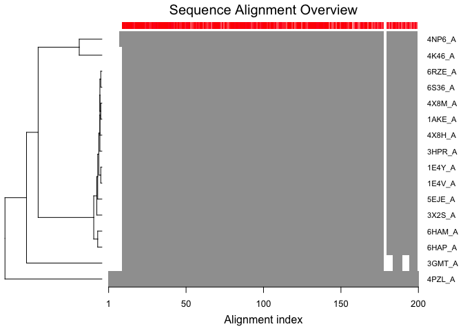

```r
# Vector containing PDB codes for figure axis
ids <- basename.pdb(pdbs$id)

# Draw schematic alignment
plot(pdbs, labels=ids)
```

Figure 2: Schematic representation of alignment. Grey regions depict aligned residues, while white depict gap regions. The red bar at the top depict sequence conservation.

## Optional: Viewing our superposed structures

We can view our superposed results with the new **bio3d.view** `view()` function:

```r
library(bio3d.view)
library(rgl)

view(pdbs)
```

[interactive chart not shown]

Figure 3: 3D view of superposed ADK structures available in the PDB.

# 3. Annotate collected PDB structures

The function `pdb.annotate()` provides a convenient way of annotating the PDB files we have collected. Below we use the function to annotate each structure to its source species. This will come in handy when annotating plots later on:

```r
anno <- pdb.annotate(ids)
print(unique(anno$source))
```

```
## [1] "Escherichia coli"          "Photobacterium profundum"
## [3] "Vibrio cholerae"           "Burkholderia pseudomallei"
## [5] "Francisella tularensis"
```

We can view all available annotation data:

```r
anno
```

|  | structureId | chainId | experimentalTechnique | resolution | ligandId | ligandName | source | scopDomain | classification | compound | title | citationAuthor | journalName | publicationYear | structureTitle | depositionDate | structureMolecularWeight | macromoleculeType | entityId | sequence | chainLength | db_id | db_name | rObserved | rFree | spaceGroup | citation |
| --- | --- | --- | --- | --- | --- | --- | --- | --- | --- | --- | --- | --- | --- | --- | --- | --- | --- | --- | --- | --- | --- | --- | --- | --- | --- | --- | --- |
| 1AKE_A | 1AKE | A | X-RAY DIFFRACTION | 2.0 | AP5 | BIS(ADENOSINE)-5'-PENTAPHOSPHATE | Escherichia coli | Microbial and mitochondrial ADK, insert "zinc finger" domain#Adenylate kinase#Adenylate kinase | TRANSFERASE(PHOSPHOTRANSFERASE) | ADENYLATE KINASE | Structure of the complex between adenylate kinase from Escherichia coli and the inhibitor Ap5A refined at 1.9 A resolution. A model for a catalytic transition state. | Muller, C.W., Schulz, G.E. | J.Mol.Biol. | 1992 | STRUCTURE OF THE COMPLEX BETWEEN ADENYLATE KINASE FROM ESCHERICHIA COLI AND THE INHIBITOR AP5A REFINED AT 1.9 ANGSTROMS RESOLUTION: A MODEL FOR A CATALYTIC TRANSITION STATE | 1991-11-08 | 49072.79 | Protein | 1 | MRIILLGAPGAGKGTQAQFIMEKYGIPQISTGDMLRAAVKSGSELGKQAKDIMDAGKLVT…… | 214 | P69441 | UniProt | 0.196 | NA | P 21 2 21 | Muller et al. J.Mol.Biol. (1992) |
| 4X8M_A | 4X8M | A | X-RAY DIFFRACTION | 2.6 | NA | NA | Escherichia coli | NA | TRANSFERASE | Adenylate kinase | Structural basis for catalytically restrictive dynamics of a high-energy enzyme state. | Kovermann, M., Aden, J., Grundstrom, C., Elisabeth Sauer-Eriksson, A., Sauer, U.H., Wolf-Watz, M. | Nat Commun | 2015 | Crystal structure of E. coli Adenylate kinase Y171W mutant | 2014-12-10 | 23643.06 | Protein | 1 | MRIILLGAPGAGKGTQAQFIMEKYGIPQISTGDMLRAAVKSGSELGKQAKDIMDAGKLVT…… | 214 | P69441 | UniProt | 0.249 | 0.309 | C 1 2 1 | Kovermann et al. Nat Commun (2015) |
| 6S36_A | 6S36 | A | X-RAY DIFFRACTION | 1.6 | CL,MG,NA | CHLORIDE ION,MAGNESIUM ION,SODIUM ION | Escherichia coli | NA | TRANSFERASE | Adenylate kinase | Nucleation of an Activating Conformational Change by a Cation-pi Interaction. | Rogne, P., Andersson, D., Grundstrom, C., Sauer-Eriksson, E., Linusson, A., Wolf-Watz, M. | Biochemistry | 2019 | Crystal structure of E. coli Adenylate kinase R119K mutant | 2019-06-24 | 23769.97 | Protein | 1 | MRIILLGAPGAGKGTQAQFIMEKYGIPQISTGDMLRAAVKSGSELGKQAKDIMDAGKLVT…… | 214 | P69441 | UniProt | 0.163 | 0.236 | C 1 2 1 | Rogne et al. Biochemistry (2019) |
| 6RZE_A | 6RZE | A | X-RAY DIFFRACTION | 1.69 | CL,NA | CHLORIDE ION,SODIUM ION | Escherichia coli | NA | TRANSFERASE | Adenylate kinase | Nucleation of an Activating Conformational Change by a Cation-pi Interaction. | Rogne, P., Andersson, D., Grundstrom, C., Sauer-Eriksson, E., Linusson, A., Wolf-Watz, M. | Biochemistry | 2019 | Crystal structure of E. coli Adenylate kinase R119A mutant | 2019-06-13 | 23673.79 | Protein | 1 | MRIILLGAPGAGKGTQAQFIMEKYGIPQISTGDMLRAAVKSGSELGKQAKDIMDAGKLVT…… | 214 | P69441 | UniProt | 0.186 | 0.235 | C 1 2 1 | Rogne et al. Biochemistry (2019) |
| 4X8H_A | 4X8H | A | X-RAY DIFFRACTION | 2.5 | NA | NA | Escherichia coli | NA | TRANSFERASE | Adenylate kinase | Structural basis for catalytically restrictive dynamics of a high-energy enzyme state. | Kovermann, M., Aden, J., Grundstrom, C., Elisabeth Sauer-Eriksson, A., Sauer, U.H., Wolf-Watz, M. | Nat Commun | 2015 | Crystal structure of E. coli Adenylate kinase P177A mutant | 2014-12-10 | 23593.99 | Protein | 1 | MRIILLGAPGAGKGTQAQFIMEKYGIPQISTGDMLRAAVKSGSELGKQAKDIMDAGKLVT…… | 214 | P69441 | UniProt | 0.196 | 0.289 | C 1 2 1 | Kovermann et al. Nat Commun (2015) |
| 3HPR_A | 3HPR | A | X-RAY DIFFRACTION | 2.0 | AP5 | BIS(ADENOSINE)-5'-PENTAPHOSPHATE | Escherichia coli | NA | TRANSFERASE | Adenylate kinase | Rational modulation of conformational fluctuations in adenylate kinase reveals a local unfolding mechanism for allostery and functional adaptation in proteins. | Schrank, T.P., Bolen, D.W., Hilser, V.J. | Proc.Natl.Acad.Sci.USA | 2009 | Crystal structure of V148G adenylate kinase from E. coli, in complex with Ap5A | 2009-06-04 | 48988.63 | Protein | 1 | MRIILLGAPGAGKGTQAQFIMEKYGIPQISTGDMLRAAVKSGSELGKQAKDIMDAGKLVT…… | 214 | P69441 | UniProt | 0.21 | 0.243 | P 21 21 2 | Schrank et al. Proc.Natl.Acad.Sci.USA (2009) |
| 1E4V_A | 1E4V | A | X-RAY DIFFRACTION | 1.85 | AP5 | BIS(ADENOSINE)-5'-PENTAPHOSPHATE | Escherichia coli | Microbial and mitochondrial ADK, insert "zinc finger" domain#Adenylate kinase#Adenylate kinase | TRANSFERASE(PHOSPHOTRANSFERASE) | Adenylate kinase | Crystal structures of two mutants of adenylate kinase from Escherichia coli that modify the Gly-loop. | Muller, C.W., Schulz, G.E. | Proteins | 1993 | Mutant G10V of adenylate kinase from E. coli, modified in the Gly-loop | 2000-07-12 | 49156.95 | Protein | 1 | MRIILLGAPVAGKGTQAQFIMEKYGIPQISTGDMLRAAVKSGSELGKQAKDIMDAGKLVT…… | 214 | P69441 | UniProt | 0.196 | NA | P 21 2 21 | Muller et al. Proteins (1993) |
| 5EJE_A | 5EJE | A | X-RAY DIFFRACTION | 1.9 | AP5,CO | BIS(ADENOSINE)-5'-PENTAPHOSPHATE,COBALT (II) ION | Escherichia coli | NA | TRANSFERASE | Adenylate kinase | Structural basis for ligand binding to an enzyme by a conformational selection pathway. | Kovermann, M., Grundstrom, C., Sauer-Eriksson, A.E., Sauer, U.H., Wolf-Watz, M. | Proc. Natl. Acad. Sci. U.S.A. | 2017 | Crystal structure of E. coli Adenylate kinase G56C/T163C double mutant in complex with Ap5a | 2015-11-01 | 49286.92 | Protein | 1 | MRIILLGAPGAGKGTQAQFIMEKYGIPQISTGDMLRAAVKSGSELGKQAKDIMDACKLVT…… | 214 | P69441 | UniProt | 0.189 | 0.236 | P 21 2 21 | Kovermann et al. Proc. Natl. Acad. Sci. U.S.A. (2017) |
| 1E4Y_A | 1E4Y | A | X-RAY DIFFRACTION | 1.85 | AP5 | BIS(ADENOSINE)-5'-PENTAPHOSPHATE | Escherichia coli | Microbial and mitochondrial ADK, insert "zinc finger" domain#Adenylate kinase#Adenylate kinase | TRANSFERASE(PHOSPHOTRANSFERASE) | Adenylate kinase | Crystal structures of two mutants of adenylate kinase from Escherichia coli that modify the Gly-loop. | Muller, C.W., Schulz, G.E. | Proteins | 1993 | Mutant P9L of adenylate kinase from E. coli, modified in the Gly-loop | 2000-07-12 | 49189.04 | Protein | 1 | MRIILLGALVAGKGTQAQFIMEKYGIPQISTGDMLRAAVKSGSELGKQAKDIMDAGKLVT…… | 214 | P69441 | UniProt | 0.178 | NA | P 1 21 1 | Muller et al. Proteins (1993) |
| 3X2S_A | 3X2S | A | X-RAY DIFFRACTION | 2.8 | AP5,JPY,MG | BIS(ADENOSINE)-5'-PENTAPHOSPHATE,N-(pyren-1-ylmethyl)acetamide,MAGNESIUM ION | Escherichia coli | NA | TRANSFERASE | Adenylate kinase | Excimer Emission Properties on Pyrene-Labeled Protein Surface: Correlation between Emission Spectra, Ring Stacking Modes, and Flexibilities of Pyrene Probes. | Fujii, A., Sekiguchi, Y., Matsumura, H., Inoue, T., Chung, W.S., Hirota, S., Matsuo, T. | Bioconjug.Chem. | 2015 | Crystal structure of pyrene-conjugated adenylate kinase | 2014-12-31 | 50254.74 | Protein | 1 | MRIILLGAPGAGKGTQAQFIMEKYGIPQISTGDMLRAAVKSGSELGKQAKDIMDCGKLVT…… | 214 | A0A0J9X1X4 | UniProt | 0.207 | 0.256 | P 21 21 21 | Fujii et al. Bioconjug.Chem. (2015) |

[output cut: 6 more lines]

# 4. Principal component analysis

Function `pca()` provides principal component analysis (PCA) of the structure data. PCA is a statistical approach used to transform a data set down to a few important components that describe the directions where there is most variance. In terms of protein structures PCA is used to capture major structural variations within an ensemble of structures.

PCA can be performed on the structural ensemble (stored in the pdbs object) with the function `pca.xyz()`, or more simpley `pca()`.

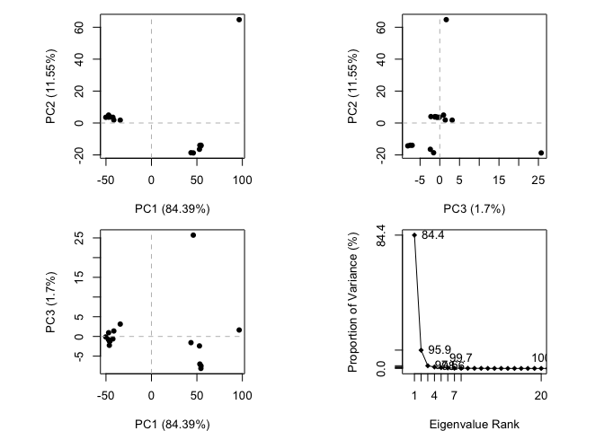

```r
# Perform PCA
pc.xray <- pca(pdbs)
plot(pc.xray)
```

Figure 4: Results of PCA on Adenylate kinase X-ray structures. Each dot represents one PDB structure.

Function `rmsd()` will calculate all pairwise RMSD values of the structural ensemble. This facilitates clustering analysis based on the pairwise structural deviation:

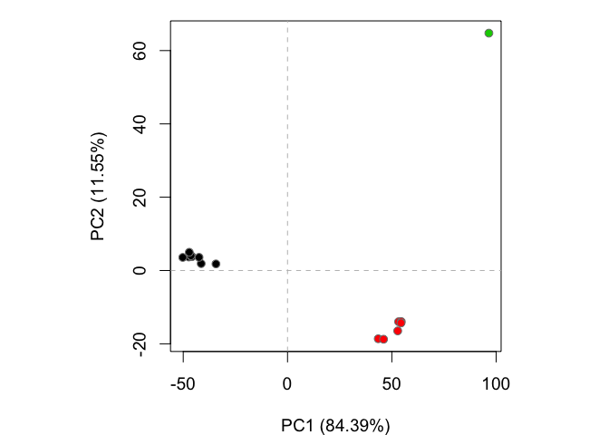

```r
# Calculate RMSD
rd <- rmsd(pdbs)

# Structure-based clustering
hc.rd <- hclust(dist(rd))
grps.rd <- cutree(hc.rd, k=3)

plot(pc.xray, 1:2, col="grey50", bg=grps.rd, pch=21, cex=1)
```

Figure 5: Projection of Adenylate kinase X-ray structures. Each dot represents one PDB structure.

The plot shows a conformer plot – a low-dimensional representation of the conformational variability within the ensemble of PDB structures. The plot is obtained by projecting the individual structures onto two selected PCs (e.g. PC-1 and PC-2). These projections display the inter-conformer relationship in terms of the conformational differences described by the selected PCs.

To visualize the major structural variations in the ensemble the function `mktrj()` can be used to generate a trajectory PDB file by interpolating along a give PC (eigenvector):

```r
# Visualize first principal component
pc1 <- mktrj(pc.xray, pc=1, file="pc_1.pdb")
```

# 5. Optional further visualization

We can also view our results with the new **bio3d.view** `view()` function:

```r
view(pc1)
```

```
## Potential all C-alpha atom structure(s) detected: Using calpha.connectivity()
```

[interactive chart not shown]

Figure 7: Visualization of PC-1 trajectory generated using `mktrj()`.

We can also plot our main PCA results with **ggplot**:

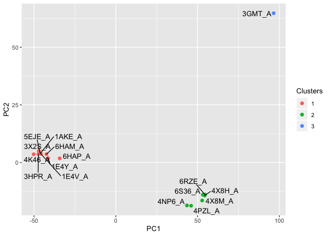

```r
#Plotting results with ggplot2
library(ggplot2)
library(ggrepel)

df <- data.frame(x=pc.xray$z[,1], y=pc.xray$z[,2])
col <- as.factor(grps.rd)

p <- ggplot(df, aes(x, y)) +
 geom_point(aes(col=col), size=2) +
 xlab("PC1") +
 ylab("PC2") +
 scale_color_discrete(name="Clusters") +
 geom_text_repel(aes(label=ids))
p
```

# 6. Normal mode analysis

Function `nma()` provides normal mode analysis (NMA) on both single structures (if given a singe PDB input object) or the complete structure ensemble (if provided with a PDBS input object). This facilitates characterizing and comparing flexibility profiles of related protein structures.

```r
# NMA of all structures
modes <- nma(pdbs)
```

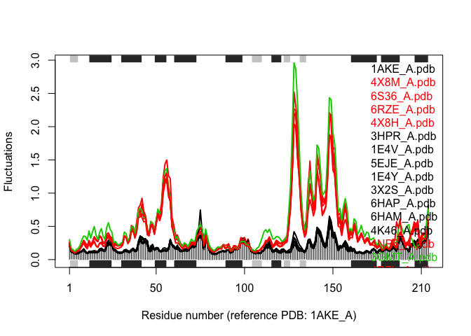

```r
plot(modes, pdbs, col=grps.rd)
```

**Q.** What do you note about this plot? Are the black and colored lines similar or different? Where do you think they differ most and why?

Collectively these results indicate the existence of two major distinct conformational states for Adk. These differ by a collective low frequency displacement of two nucleotide-binding site regions that display distinct flexibilities upon nucleotide binding.

> **Important-Note**: Remember to save your R markdown script document and Knit to generate a GitHub format .md report. Then **stage**, **commit** and **push** both these documents to GitHub by following the steps outlined in the last class - ask Barry if you are unsure of this process.

Powered by [labsheet](https://github.com/bioboot/labsheet/)